# R & Probabilities Intro

[This is how exercises are highlighted]

[This is how your answers are highlighted]

# Introduction

Basic R concepts (variables, functions, indexing, …) are introduced along the way and as needed. This notebook aims to give you a feel for the vast R possibilities, and to introduce you to an iterative try-and-debug work mode that equips you with the intuition and tools necessary to learn more as you progress and become a more proficient R programmer (or R user).

Download the `.Rmd` file by clicking `Code > Download Rmd` in the top-right corner. Open the file in RStudio, locate this very line in the file, and continue from there.

# R & RStudio basics

Code is executed using the green triangular run button at the top right of code chunks, using `Ctrl+Enter` or `Cmd+Enter` for running the individual line your cursor is currently on, or using `Ctrl+Shift+Enter` or `Cmd+Shift+Enter` to run individual code chunks.

Execute the code below and have R compute the mean of two variables `a` and `b` for you:

```r
a <- 13; b <- 42
a_and_b_combined <- c(a,b)
mean(a_and_b_combined)
```

```
## [1] 27.5
```

Upon successful completion of the above code chunk, R should output the arithmetic mean $\frac{13 + 42}{2}$ of $13$ and $42$.

**A note on coding style**: Readability of code goes a long way. For starters, and instead of reading the [tidyverse style guide](https://style.tidyverse.org/) and learning it off by heart, some general advice is: use consistent syntax, prefer short over long code lines, and have at most one statement per line. While learning R, it is a good idea to select code blocks you have written and to hit `Ctrl+Shift+A` – this will reformat your code and thus give you feedback on how to write better-structured code. You may try this straight away for the code chunk above – you will notice that RStudio’s reformatter splits the statements over lines and inserts a space after the comma.

**Help: `?` is generally a good idea**

R packages and functions are usually well documented. While the exhaustive documentation may be overwhelming in the beginning, it is invaluable to be able to extract relevant information from documentation (and the internet more generally). Even the most well-versed coders may struggle to develop anything while their access to documentation and the internet is capped. That is, we will often spend (at least) as much time on reading about some function and its options as we spend on writing actual code lines.

# Sampling from finite sets

We can use the function `sample()` to obtain a sample from a finite set.

```r
# sample one value from {1,2,3} with equal probability
sample(1:3, size = 1)
```

```
## [1] 3
```

We can also specify the probabilities of the elementary events.

```r
sample(c("red", "blue"), size = 1, prob = c(0.25, 0.75))
```

```
## [1] "blue"
```

The vector of probabilities does not need to be normalized.

```r
sample(1:10, size = 1, prob = 1:10)
```

```
## [1] 5
```

1. Create a function called `rollDie` that take as input the number $n$ of faces of a die and returns a random natural number between $1$ and $n$, that is , simulate rolling a $n$-sided die.

```r
rollDie <- function(n) {
  return(sample(n, size = 1))
}
```

## Sampling with replacement

```r
sample(c("heads", "tails"), size = 10, replace = TRUE)
```

```
##  [1] "tails" "heads" "heads" "heads" "heads" "heads" "heads" "heads" "tails"
## [10] "tails"
```

2. What happens if we call `sample(c(1:3), size = 10)`, can you explain it?
3. Implement a function that implements the random experiment of tossing a coin $n$ times, and returns the total number of heads in the sequence.
4. What does the simple function call `sample(4)` do? (Hint: `?sample`)
2. Let’s see what happens

```r
sample(c(1:3), size = 10)
```

```
## Error in sample.int(length(x), size, replace, prob): cannot take a sample larger than the population when 'replace = FALSE'
```

We get an error, since it is impossible to sample 10 times from {1, 2, 3} without replacement.

We may instead sample with replacement

```r
sample(c(1:3), size = 10, replace = TRUE)
```

```
##  [1] 3 1 1 2 1 3 3 2 3 2
```

or sample $\leq 3$ times (without replacement)

```r
sample(c(1:3), size = 3)
```

```
## [1] 3 1 2
```

```r
sample(c(1:3), size = 2)
```

```
## [1] 3 1
```

3. To implement this function, we rely on `rollDie` and take $1$ to correspond to tail, and $2$ to head:

```r
no_heads <- function(n) {
  coin_flips <- replicate(n, rollDie(2))
  return(sum(coin_flips == 2))
}
```

4. Let’s see what happens

```r
sample(4)
```

```
## [1] 1 3 4 2
```

```r
sample(4)
```

```
## [1] 1 4 3 2
```

Consulting the help `?sample`, we find

> If x has length 1, is numeric (in the sense of is.numeric) and x >= 1, sampling via sample takes place from 1:x.

That is, `sample(4)` is sampling from `1:4 = c(1:4) = c(1, 2, 3, 4)`.

Furthermore, in the help

> For sample the default for size is the number of items inferred from the first argument, so that sample(x) generates a random permutation of the elements of x (or 1:x).

That is, `sample(4)` generates a random permutation of the elements `c(1, 2, 3, 4)`.

# Example: Blood types genetics

In classical genetics, we recognize three alleles for the ABO gene that regulates ABO blood type: $i$, $I^A$, and $I^B$ . Any individual inherits a complete set of chromosomes from its two parents and thus the genotype of an individual is a pair of alleles (the order is not important).

## Sample space

Describe the sample space $\Omega$ related to the genotype of an individual.

$$\Omega = \{ \{ i, i \}, \{ i, I^A \} , \{ i, I^B \} , \{ I^A, I^B \} ,
\{ I^A, I^A \}, \{ I^B, I^B \} \}$$

$$|\Omega| = 6 = 2 \times 3$$

How can we simulate a random individual genotype? (use the *sample* function).

We use the `sample` function in R, and we represent genotypes with vectors.

```r
randomGenotype <- function(alleles = c("i", "A", "B")) {
  sample(alleles, size = 2, replace = T)
}

randomGenotype()
```

```
## [1] "A" "A"
```

## Random Variable: Phenotype

We know that even if there are $6$ genotypes (the sample space $\Omega$), the possible phenotypes are only the following $4$:

- **Type A** produced by $I^AI^A$ and $I^Ai$
- **Type B** produced by $I^BI^B$ and $I^Bi$
- **Type AB** produced by $I^AI^B$
- **Type 0** produced by $ii$

Observe that the mapping from genotype to phenotype is an example of an “extended” random variable.

Create a function that computes the phenotype from the genotype.

```r
genotype2phenotype <- function(genotype) {
  if (all(genotype == "i")) {
    return("Type O")
  } else if ("i" %in% genotype) {
    return(paste("Type", genotype[genotype != "i"]))
  } else if (genotype[1] == genotype[2]) {
    return(paste("Type", genotype[1]))
  } else{
    return("Type AB")
  }
}
```

Let’s test it,

```r
genotype2phenotype(c("i", "i"))
```

```
## [1] "Type O"
```

```r
genotype2phenotype(c("A", "i"))
```

```
## [1] "Type A"
```

```r
genotype2phenotype(c("i", "B"))
```

```
## [1] "Type B"
```

```r
genotype2phenotype(c("A", "A"))
```

```
## [1] "Type A"
```

```r
genotype2phenotype(c("B", "B"))
```

```
## [1] "Type B"
```

```r
genotype2phenotype(c("A", "B"))
```

```
## [1] "Type AB"
```

## Simulation: Inheritance

Suppose now that the individuals inherit from each parent randomly one of the two alleles. That is, if the two parents have alleles $\{x_1,x_2\}$ and $\{y_1,y_2\}$ respectively, then the offspring will receive $x_1$ or $x_2$ from the first parent and $y_1$ or $y_2$ from the second parent, with probabilities all equal to $0.5$. Suppose moreover that the events related to different parents are independent. From now on we use the notation $ab = \{a,b\}$ for genotypes.

Create an R function that given two genotypes returns the (random) offspring genotype.

```r
randomOffspring <- function(parent1, parent2) {
  c(sample(parent1, size = 1), sample(parent2, size = 1))
}

p1 <- randomGenotype()
p2 <- randomGenotype()

randomOffspring(p1, p2)
```

```
## [1] "A" "A"
```

If both parents have genotype $iI^A = \{ i, I^A \}$, compute the probability that the offspring will have genotype $ii$ and the probability that at least one of the two alleles will be $i$.

We can represent the situation with a table, that we can generate in R as follows

```r
parent1 <- c("i", "i^A")
parent2 <- c("i", "i^A")
offspring <- apply(
  expand.grid(parent1, parent2),
  MARGIN = 1,
  FUN = function(x) {
    return(paste(x[1], x[2]))
  }
)
matrix(
  data = offspring ,
  nrow = 2,
  dimnames = list(parent1 = parent1, parent2 = parent2)
)
```

```
##        parent2
## parent1 i       i^A
##     i   "i i"   "i i^A"
##     i^A "i^A i" "i^A i^A"
```

The possible genotypes for the offspring are
$$ii, iI^A, I^AI^A$$

The probabilities of each *cell* in the table above is $0.25$. Thus, the probabilities for the possible genotypes are,
$$P(ii) = 0.25,
\quad
P(I^AI^A) = 0.25,
\quad
P(iI^A) = 0.25 + 0.25 = 0.5.$$
Alternatively, we can use the independence assumption to say that
$$P(ii) = P(\text{parent 1 gives } i
\text{ and parent 2 gives } i) =$$

$$P(\{ \text{parent 1 gives } i \} \cap \{
\text{ parent 2 gives } i \}) =$$

$$P(\{ \text{parent 1 gives } i \} )
\times P( \{ \text{ parent 2 gives } i \}) = 0.5 \times
0.5$$
And similarly for the other possibilities.

As you can see $P(ii) + P(iI^A) + P(I^AI^A) = 1$.

Finally, we compute the required probabilities as

$$P(ii)= 0.25$$

and

$$P( \text{at least one allele is } i ) =
P( \{ ii \} \text{ or } \{ iI^A\}) = P( \{ii\} \cup \{ iI^A \})$$
$$= P(ii) + P(iI^A) = 0.75$$

using the fact that the two events $\{ ii\}$ and $\{ iI^A \}$ are disjoint.

**the power of simulation**

Approximate the probabilities based on simulations, that is, simulate a large number of samples and approximate the probability by the corresponding empirical frequency.

```r
parent1 <- c("i", "A")
parent2 <- c("i", "A")

N <- 10000
offsprings <- t(replicate(N, randomOffspring(parent1, parent2)))

# both alleles are i
pii_est <- nrow(offsprings[offsprings[, 1] == "i" &
                             offsprings[, 2] == "i", ]) / N
pii_est
```

```
## [1] 0.2507
```

```r
# at least one allele is i
pi_est <- nrow(offsprings[offsprings[, 1] == "i" |
                            offsprings[, 2] == "i", ]) / N
pi_est
```

```
## [1] 0.7512
```

## Two Generations

Suppose the following two-generations scenario:

- Parents with genotypes $iI^A$ and $iI^B$ generate offspring $A$
- Parents with genotypes $I^AI^B$ generate offspring $B$
- Parents $A$ and $B$ generate individual $C$

Compute the probability of the genotype of $C$ being $I^AI^B$.

$$\begin{aligned}
& P(\text{genotype of } C = I^A I^B) \\
= &
P(A \rightarrow C = I^A \text{ and } B \rightarrow C = I^B ) \\
+ &
P(A \rightarrow C = I^B \text{ and } B \rightarrow C = I^A)
\end{aligned}$$
where we use the notation $K \rightarrow M = zzz$ to denote the events where parent $K$ gives allele $zzz$ to offspring $M$.

We proceed now to obtain the probabilities
$$P(A \rightarrow C = I^A \text{ and } B
\rightarrow C = I^B )
\tag{first case}$$
$$P(A \rightarrow
C = I^B \text{ and } B \rightarrow C = I^A)
\tag{second case}$$

Since the events of two different parents are independent, we have that

$$\begin{aligned}
& P(A \rightarrow C = I^A \text{ and } B \rightarrow C = I^B )\\
= &
P(A \rightarrow C = I^A) \times P(B \rightarrow C = I^B)
\end{aligned}
\tag{first case}$$

To obtain, for example, $P(A \rightarrow C = I^A)$ we need to consider the possible genotypes for $A$,

Individual $A$ can have one of the four possible genotypes,
$$ii , iI^A, iI^B,
I^AI^B,$$
where
$$P(A=ii) =
P(A=iI^A) = P(A=iI^B) = P(A = I^AI^B) = 0.25\text{.}$$

Moreover we have that,
$$\begin{aligned}
P(A \rightarrow C = I^A | A = ii) &= 0 \\
P(A \rightarrow C = I^A | A = iI^A) &= 0.5 \\
P(A \rightarrow C = I^A | A = iI^B) &= 0 \\
P(A \rightarrow C = I^A | A = I^AI^B) &= 0.5
\end{aligned}$$

Thus, using the chain rule, that is, $P(A,B) = P(A | B )P(B)$, we obtain,

$$\begin{aligned}
&
P(A \rightarrow C = I^A)\\
= &0 \times 0.25 + 0.5 \times 0.25 +
0 \times 0.25 + 0.5 \times 0.25 \\
= &0.25
\end{aligned}$$

For individual $B$ we have that,
$$P(B = I^AI^A ) = P(I^BI^B) = 0.25$$
and
$$P(B = I^AI^B) = 0.5$$

and moreover,
$$\begin{aligned}
P(B \rightarrow C = I^B | B = I^AI^A) &= 0 \\
P(B \rightarrow C = I^B | B = I^AI^B) &= 0.5 \\
P(B \rightarrow C = I^B | B = I^BI^B) &= 1
\end{aligned}$$

Again using the chain rule, we obtain

$$P(B \rightarrow C = I^B) = 0 \times
0.25 + 0.5 \times 0.5
+ 1\times 0.25 = 0.5$$

We can now obtain from equation (first case) that,
$$P(A \rightarrow C = I^A \text{ and } B
\rightarrow C = I^B ) =
0.25 \times 0.5 = 0.125$$

Similarly we need to obtain,
$$\begin{aligned}
& P(A \rightarrow C = I^B \text{ and } B \rightarrow C = I^A)\\
=
&
P(A \rightarrow C = I^B) \times P(B \rightarrow C = I^A)
\end{aligned}
\tag{second case}$$

Analogous reasoning to above will lead us to
$$P(A \rightarrow C = I^B) = 0.25$$
and
$$P(B \rightarrow C = I^A) = 0.5$$

Thus,
$$P(A \rightarrow C = I^B \text{
and } B \rightarrow C = I^A)
= 0.125$$

And finally we obtain

$$\begin{aligned}
& P(\text{genotype of } C = I^A I^B) \\
= &
P(A \rightarrow C = I^A \text{ and } B \rightarrow C = I^B ) \\
& +
P(A \rightarrow C = I^B \text{ and } B \rightarrow C = I^A) \\
= &
0.125 + 0.125 = 0.25
\end{aligned}$$

Can you code up the two-generation scenario and sample $1000$ observations of the phenotype of $C$ to approximate the probability?

```r
twoGenC <- function() {
  A <- randomOffspring(c("i", "A"), c("i", "B"))
  B <- randomOffspring(c("A", "B"), c("A", "B"))

  C <- randomOffspring(A, B)
  return(list(A = A, B = B, C = C))
}

twoGenC()
```

```
## $A
## [1] "A" "B"
##
## $B
## [1] "B" "A"
##
## $C
## [1] "B" "A"
```

Sample $1000$ phenotypes of $C$

```r
phenotypesC <- replicate(1000, genotype2phenotype(twoGenC()$C))
table(phenotypesC) / 1000
```

```
## phenotypesC
##  Type A Type AB  Type B
##   0.388   0.241   0.371
```

Increase the number of observations and obtain probabilities

```r
N <- 10000
phenotypesC <- replicate(N, genotype2phenotype(twoGenC()$C))
table(phenotypesC) / N
```

```
## phenotypesC
##  Type A Type AB  Type B
##  0.3685  0.2492  0.3823
```

## Bonus 1: Probability distribution of the grand-offspring’s phenotype

Suppose the same two-generation scenario as above. Which are the possible phenotypes for $C$?

The possible genotypes are

$$\{ iI^A, iI^B, I^AI^B, I^AI^A,
I^BI^B \} = \Omega \setminus
\{ ii \}$$

The possible phenotypes are

- **Type B** from $iI^B$ or $I^BI^B$
- **Type A** from $iI^A$ or $I^AI^A$
- **Type AB** from $I^AI^B$

The only phenotype that individual $C$ cannot be is **Type 0**.

Can you describe the probability distribution of the phenotype of $C$?

## Bonus 2: Conditional probability

What is the conditional probability of the phenotype of $C$ being Type B given that the genotype of $B$ is $I^AI^B$?

Observe that
$$P(B \to C = I^A | B = I^AI^B) = 0.5
= P(B \to C = I^A)$$
and
$$P(B \to C = I^B | B = I^AI^B) = 0.5
= P(B \to C = I^B)$$
that is, the probabilities that $B$ passes on $I^A$ or $I^B$, here knowing that $B = I^AI^B$, are the same as above (where we only knew the genotypes of its parents). Thus, we obtain that
$$\begin{aligned}
&
P(\text{genotype of } C = I^AI^B | B = I^AI^B)\\
= &
P(\text{genotype of } C = I^AI^B) \\
= &
0.25
\end{aligned}$$
and therefore
$$\begin{aligned}
P(\text{phenotype } C = \text{ Type B } | B = I^AI^B)
= 0.375
\end{aligned}$$

# Distributions

For most common distributions there are already helper functions available in R.

## Cumulative distribution function

Cumulative distribution functions are implemented and named `p{name of the distribution}`

We have, for example:

1. The binomial distribution

```r
pbinom(3, size = 10, prob = 0.3)
```

```
## [1] 0.6496107
```

2. The Poisson distribution

```r
ppois(q = 10, lambda = 4)
```

```
## [1] 0.9971602
```

3. The Gaussian distribution

```r
pnorm(0, mean = 0, sd = 3)
```

```
## [1] 0.5
```

4. The Beta distribution

```r
pbeta(q = 0.5, shape1 = 10, shape2 = 3)
```

```
## [1] 0.01928711
```

It is easy to plot these cdfs with the `curve` function, for example:

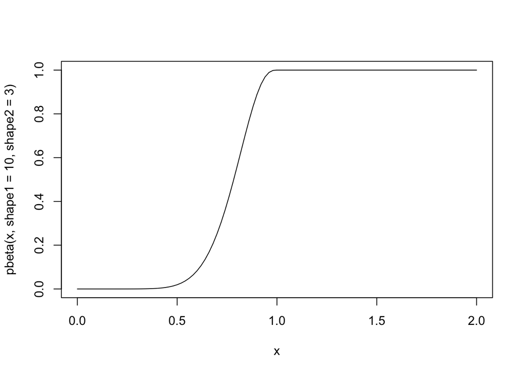

```r
curve(pbeta(x, shape1 = 10, shape2 = 3), from = 0 , to = 2)
```

## Density and probability mass function

The probability density (or mass) functions are likewise canonically named as `d{name of the distribution`}.

```r
# probability of exactly 24 out of 100 successes
# where the probability of success in each trial is .45
dbinom(24, size = 100, prob = .45)
```

```
## [1] 7.023238e-06
```

```r
# value of the pdf of a N(3, 1) Gaussian variable at 0
dnorm(x = 0, mean = 3, sd = 1)
```

```
## [1] 0.004431848
```

Again, we can use the `curve` function to plot density functions. Below an example where we plot densities of a Gaussian random variable for different values of the standard deviation.

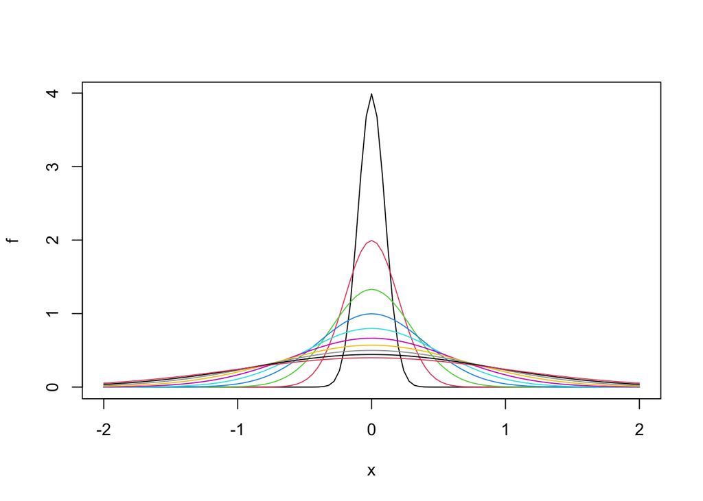

```r
first_plot <- FALSE
for (sd in  seq(from = 0.1, to = 1, by = 0.1)) {
  curve(
    dnorm(x, mean = 0, sd = sd),
    add = first_plot,
    from = -2,
    to = +2,
    col = 10 * sd,
    ylab = "f"
  )
  first_plot = TRUE
}
```

5. Plot the densities of the exponential distribution, for different values of the `rate` parameter, into one set of axes. Try also to add a legend and choose an appropriate interval for both the x-axis and the rate parameters.
6. Compute the probability that a random variable $X \sim N(\mu, 1) \in [0,1]$ for different values of $\mu = -4, -2, 0, 2 , 4$. Find the $\mu$ for which this probability is maximal.
5. We can build off the example above for Gaussian densities.

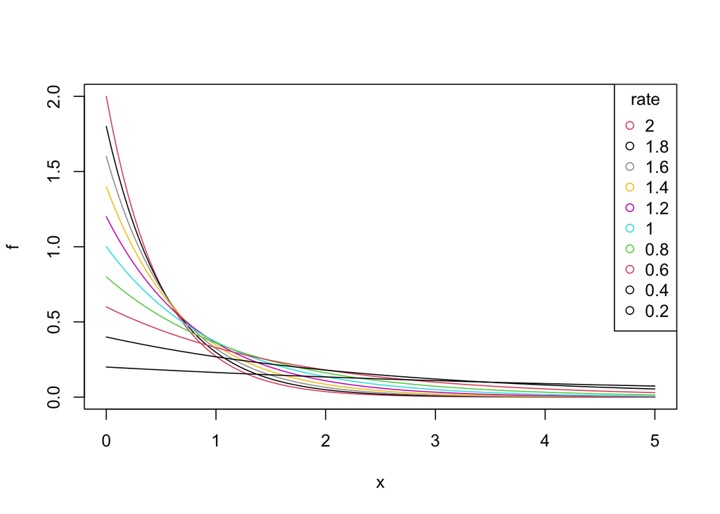

```r
first_plot <- FALSE
rates <- seq(from = 2, to = .2, by = -.2)
for (rate in rates) {
  curve(
    dexp(x, rate = rate),
    add = first_plot,
    from = 0,
    to = 5,
    ylab = "f",
    col = 5 * rate,
  )
  first_plot = TRUE
}
legend("topright",
       sapply(rates, toString),
       col = rates * 5,
       pch = 1,
       title = "rate",
       )
```

Here, `first_plot` is set to `TRUE` after the first curve has been plotted (`first_plot == TRUE` if the first plot has been plotted); for subsequent plots, we set the parameter `add = TRUE`, which results in the subsequent curves to be added to the same plot.

6. We are interested in the probabiity that a Gaussian variable takes value in the interval $[0, 1]$. Given a cdf $F$, we can compute the probability as $P(X \in [0, 1]) = F(1) - F(0)$. The cdf of a Gaussian in R is implemented as `pnorm(x, mean = mean)`. Now, we obtain the probabilities as

```r
# a helper function that returns the probability
# of a Gaussian to take value in [0, 1]
# and takes as input the mean of the Gaussian
helper <- function(mu) {
  return(pnorm(1, mean = mu) - pnorm(0, mean = mu))
}
# The probabilities can be obtained via
sapply(c(-4, -2, 0, 2, 4),
       helper)
```

```
## [1] 3.138459e-05 2.140023e-02 3.413447e-01 1.359051e-01 1.318227e-03
```

To find the maximum, we can reason that the Gaussian is symmetric and unimodal, so we expect the highest probabiity, when centering the Gaussian wrt the interval $[0, 1]$. That is, for $\mu = 0.5$ we expect the probability to be maximal.

```r
helper(0.5)
```

```
## [1] 0.3829249
```

We could have instead used `optimize` which minimizes a function (refer to `?optimize`):

```r
# as optimize minimizes,
# we take the negative of the function helper;
# the minimum of -helper(x)
# corresponds to the maximum of +helper(x)
opt <- optimize(
  function(x) -helper(x),
  c(-100, 100))
helper(opt$minimum)
```

```
## [1] 0.3829249
```

# Sampling from known distributions

To generate an iid sample from a given distribution, we can use the family of functions `r{name of the distribution}`. Here, an iid sample referes to a collection of observations that were obtained independently and identically distributed.

For example the following expression generates an iid sample of size 5 from the uniform distribution in the interval $[10, 17]$,

```r
runif(n = 5, min = 10, max = 17)
```

```
## [1] 10.74126 15.05202 10.40318 10.84652 16.55017
```

An iid sample of size $10$ from a Binomial distribution with parameters $\text{size} = 100, p = 0.3$,

```r
rbinom(10, size = 100, prob = 0.3)
```

```
##  [1] 27 27 32 36 27 34 29 26 27 28
```

7. Sample $100$ iid observations from a Gaussian distribution with mean $0$ and variance $1$.
8. Generate an iid sample of $10$ observations from $\operatorname{Uniform}([0,5])$ and compute the maximum of the values. Repeat with sample sizes $50,100$, and $1000$.
9. Implement a function that simualtes $1$ observation from a Binomial distribution with given parameters $n,p$, without using `rbinom`.
7. This can be accomplished by `rnorm`:

```r
obs <- rnorm(100, mean = 0, sd = 1)
```

8. We can sample from a uniform with `runif` and compute the maximum with `max`, that is

```r
max(runif(10, min = 0, max = 5))
```

```
## [1] 4.009146
```

```r
max(runif(50, min = 0, max = 5))
```

```
## [1] 4.980864
```

```r
max(runif(100, min = 0, max = 5))
```

```
## [1] 4.981016
```

```r
max(runif(1000, min = 0, max = 5))
```

```
## [1] 4.998908
```

9. We exploit the relationship between a Binomial and the total number of heads in $n$ independent repetitions of a $p$-biased coin flip.

```r
our_rbinom <- function(n, p) {
  n_flips <- sample(2,
                    size = n,
                    replace = TRUE,
                    prob = c(p, 1 - p))
  return(sum(n_flips == 1))
}
```

Instead we could have also used a sample from the uniform distribution as follows

```r
our_rbinom_2 <- function(n, p) {
    n_unifs <- runif(n)
    return(sum(n_unifs < p))
}
```